# A simulation approach to determine statistical significance of species turnover peaks in a species‐rich tropical cloud forest - Bach - 2007 - Diversity and Distributions - Wiley Online Library

[Diversity and Distributions](https://onlinelibrary.wiley.com/journal/14724642)

[Volume 13, Issue 6](https://onlinelibrary.wiley.com/toc/14724642/2007/13/6)

[figure not shown]

Open Access

# A simulation approach to determine statistical significance of species turnover peaks in a species‐rich tropical cloud forest

[K. Bach](https://onlinelibrary.wiley.com/action/doSearch?ContribAuthorStored=Bach%2C+K)

Correspondence: K. Bach, Albrecht von Haller Institute of Plant Sciences, Department of Systematic Botany, University of Göttingen, Untere Karspüle 2, 37073 Göttingen, Germany E‐mail:

[M. Kessler](https://onlinelibrary.wiley.com/action/doSearch?ContribAuthorStored=Kessler%2C+M)

[S. R. Gradstein](https://onlinelibrary.wiley.com/action/doSearch?ContribAuthorStored=Gradstein%2C+S+R)

First published: 16 April 2007

https://doi.org/10.1111/j.1472-4642.2007.00357.x

Citations: 14

## INTRODUCTION

Since Humboldt's (1807) classical work on altitudinal zonation, elevational vegetation belts in tropical high mountains have been documented numerous times (e.g. Holdridge *et al*., 1971; Grubb, 1974; Ellenberg, 1975; Frahm & Gradstein, 1991; Lieberman *et al*., 1996; Vázquez & Givnish, 1998). A recent UNESCO survey (Bruijnzeel & Hamilton, 2000) accepted four elevational belts on humid mountain slopes: lowland forest, lower montane cloud forest, upper montane cloud forest, and subalpine cloud forest. Since mean air temperature changes continuously with elevation, limits of vegetation belts are usually defined by discontinuities in air humidity or by the occurrence of biologically meaningful temperature parameters such as frost (Holdridge *et al*., 1971; Grubb, 1974). Botanical characterization of vegetation zones is mostly based on observed changes in forest structure and species composition, or on species turnover (= β‐diversity; Whittaker, 1960).

Various indices reflecting different aspects of spatial turnover are used in studies on β‐diversity (Magurran, 2004). All of these indices measure the proportion of shared species, and of those lost and gained moving from one area to next, and are highly influenced by area and species richness (Koleff *et al*., 2003). A further problem is the application of significance tests on the results. A number of statistical models have been developed (Pielou, 1977; Underwood, 1978; Shipley & Keddy, 1987; Dale, 1988; Gotelli & Graves, 1996), but the validity of all of these is questionable due to the sensitivity of the underlying statistical assumptions to frequently observed violations as well as to variations in species richness and sampling intensity. To overcome these problems we developed a simulation approach based on randomization of species distributions and applied this to a case study on ferns, aroids, bromeliads, and melastomes in a species‐rich tropical cloud forest in the Bolivian Andes.

## METHODS

### Study area

The study area is located in tropical cloud forests of the Bolivian Yungas in Cotapata National Park (67°43′−68°03′ W/16°05′−16°20′ S), *c*. 80 km NE of La Paz. Moraes & Beck (1992) recorded almost 1500 species of vascular plants in the mountain forests of the Yungas, and Krömer & Gradstein (2003) reported *c*. 300 species of vascular epiphytes from Cotapata National Park. In the present study, we analysed a 5.2‐km long transect between 1700 m and 3400 m on the south‐eastern slope of Cerro Hornuni (67°55′ W/16°11′ S, 3650 m). Average air temperature at midday along the transect decreased from *c*. 17 °C to 10 °C while annual precipitation increased from 2300 mm to over 5000 mm (Schawe, 2005). Very steep slopes and frequent occurrence of natural landslides are characteristic for the area. Soils are very acid (pH < 4.5), and podsolization and soil wetness increases markedly with elevation (Gerold *et al*., 2003). The forest vegetation was undisturbed by humans except for traces of former mining activities at 2600–2700 m. The summit area of Cerro Hornuni is covered by humid páramo vegetation, whereas drought‐deciduous forest fragments occur near the valley bottom, below 1700 m.

### Vegetation sampling

All species of the selected plant groups (ferns, aroids, bromeliads, melastomes) were sampled in 101 plots of 400 m<sup>2</sup> each in zonal forest vegetation, avoiding landslides and forest gaps. Plots were positioned in two replicates at about 50 m elevational intervals. Plots above the forest line at *c*. 3000 m were located in shrubby forest remnants with rather open canopy. In each plot, species were recorded using the standard Braun–Blanquet approach (Mueller‐Dombois & Ellenberg, 1974). Epiphytes were recorded using binoculars and collected from fallen trees and branches. Species identification was carried out by specialists, and vouchers have been deposited in the National Herbarium of Bolivia (LPB), Herbarium Göttingen (GOET), and by the respective specialists.

### Data analysis

For each species, range sizes were calculated as the difference between the upper‐ and the lowermost records in elevational steps at resolutions of 100 m and 200 m, respectively. Species recorded from only one elevation were excluded from the analysis, upper‐ and lowermost limits at the same elevation being uninformative about species turnover while species richness might be blurred by sampling biases at these resolutions. Of the total of 319 species sampled (220 ferns, 56 melastomes, 22 aroids, 21 bromeliads), 239 were included in the 100‐m step analysis and 226 in the 200‐m analysis. Analyses were conducted separately for epiphytes (168 species) and terrestrial species (140; hemiepiphytic aroids excluded), and for the fern families Lomariopsidaceae (48 species) and Hymenophyllaceae (26). The latter two are the largest fern families in the study region and provide insight into the phylogenetic and ecological diversity of the ferns.

Species turnover was determined by counting the upper and lower distribution limits per elevational step and by calculating the Wilson–Shmida similarity index (Wilson & Shmida, 1984) between adjacent steps. This index is one of the most frequently used indices and results are comparable to those of other β‐diversity indices (Davis *et al*., 1999; Koleff *et al*., 2003; Magurran, 2004). Because sampling area was constant, no area‐sensitive index was applied.

### Simulation

To determine whether the observed variation in species turnover was due to stochastic variation of species elevational distributions or due to significant accumulations of species range limits, Monte Carlo simulations were applied. Observed elevational range amplitudes of species were placed randomly on a virtual elevational gradient in different layers constraining total species numbers per elevational step according to the expected richness pattern following the MMMean richness estimator (Raaijmakers, 1987) as implemented in EstimateS 6.0b1 (Colwell, 1997). Layers (as rows in a data table) were used to simulate different niches of the species, e.g. the different spatial preferences of terrestrial and epiphytic species, or of sun and shade epiphytes. Early simulation trials showed that not all species could be accommodated in the simulations using the observed species richness. This was a result of tight species packing in the empirical data, whereas in the randomized data many gaps between species could not be filled because they were narrower than the species ranges remaining to be placed (Herzog *et al*., 2005). Estimated richness values were therefore multiplied by 1.5, corresponding to the minimum richness increase necessary to be able to accommodate all species during randomization. After each simulation run, the three parameters of species turnover were assessed: number of upper and lower elevational limits per elevational step, and species turnover between adjacent steps (Wilson–Shmida index). The upper‐ and lowermost elevational steps of the study transect were excluded from this analysis because the actual ranges of the species might have extended beyond the study transect. Randomizations were repeated 1000 times and the mean and double standard deviations were calculated for the three parameters. These values were compared with the observed data by χ<sup>2</sup> and Kolmogoroff–Smirnov significance tests. Peaks exceeding the double standard deviations of the predicted values were tested as significant elevational limits by χ<sup>2</sup> tests between the respective and all remaining steps gathered. Analyses were carried out with systat 7.0. The simulation program is available online (see Appendix S1 in Supplementary Material).

## RESULTS

Mean elevational species range was 500 ± 368 m (Fig. 1). Hymenophyllaceae had the widest range size (760 ± 534 m) and terrestrial bromeliads the shortest (346 ± 292 m) followed by melastomes (426 ± 237 m). Generally, range sizes of terrestrial species were shorter than those of epiphytes (*t* = 2.68; *P* < 0.01). Ranges of 1600 m, almost covering the entire gradient, were found for *Blechnum lechleri* Mett. and the epiphytic ferns *Hymenophyllum axillare* Sw. and *Hymenophyllum trichomanoides* Bosch.

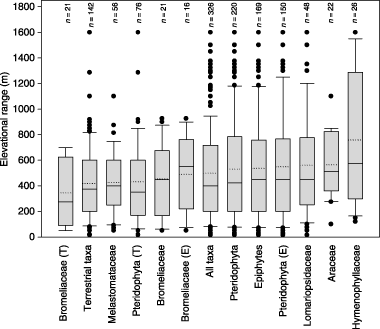

**Figure 1**

Mean range sizes of all analysed groups (dotted line — mean, straight line — median, E — epiphytes, T — terrestrial taxa).

Species turnover as expressed by the Wilson–Shmida index was highest at high elevations for most groups (Fig. 2, solid line). In the 100‐m steps analysis, turnover of terrestrial species and epiphytic bromeliads peaked at 2600 m and 2800 m, of total epiphytes at 3000 m, and of all species combined at 2600 m, 2800 m, and 3000 m. Further peaks were found at 2300 m (Araceae), 2400 m (Hymenophyllaceae), and 3200 m (Melastomataceae). Lomariopsidaceae followed the pattern of epiphytes with highest turnover values at high elevations. In the 200‐m steps analysis, Wilson–Shmida index values were higher and fewer peaks emerged (Fig. 2, dotted line). Terrestrial groups and epiphytic bromeliads had maximum turnover rates at 2700 m, whereas other epiphytic groups lacked maximum rates. Turnover of aroids, Hymenophyllaceae, and melastomes was highest at 2300 m, 2300/2500 m, and 2850 m, respectively. However, none of these peaks were significant compared to the turnover values predicted by simulation analyses.

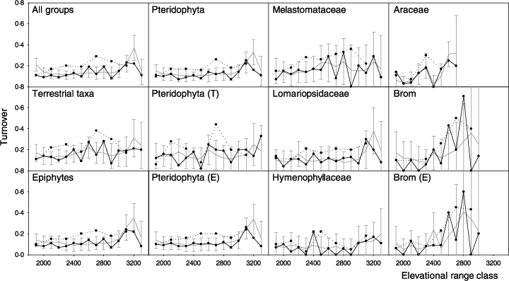

**Figure 2**

Values of the Wilson–Shmida index along the transect with elevational steps of 100 m and 200 m (observed values with steps of 100 m (bold line) and predicted values with double standard deviation (thin line), observed values of 200 m steps until 3100 m (dotted line), Brom — Bromeliaceae, E — epiphytes, T — terrestrial taxa). Wilson–Shmida index values increase towards the maximum value of 1 with increasing dissimilarity of adjacent belts.

Soil conditions showed a strong correlation between species turnover of all studied plant groups to the base saturation of the A<sub>h</sub> horizon (*r =* 0.93; *P* < 0.05 Bonferroni corrected) and to exchangeable H<sup>+</sup> ions of the A<sub>h</sub> horizon (*r =* 0.94; *P* < 0.05 Bonferroni corrected), respectively. Significant correlations with exchangeable cations (K, Mg) and total N content of the A<sub>h</sub> horizon (*P <* 0.05) were found for the species turnover of all terrestrial taxa and of epiphytic bromeliads.

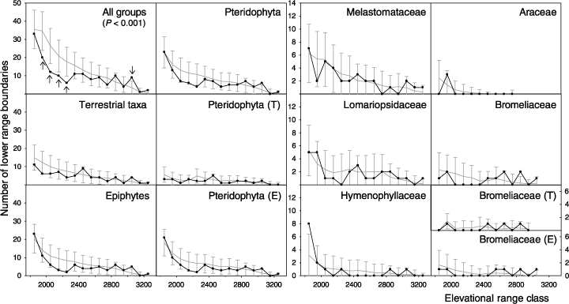

**Figure 3**

Number of lower elevational distribution limits along the transect with elevational steps of 100 m (bold line — observed values, thin line — predicted values with double standard deviation, Brom — Bromeliaceae, E — epiphytes, T — terrestrial taxa). The arrows point on elevational belts with significant deviations from the predicted values.

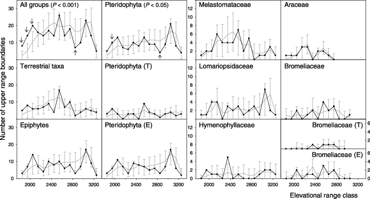

**Figure 4**

Number of upper elevational distribution limits along the transect with elevational steps of 100 m (see Fig. 3 for description).

## DISCUSSION

The significant values of species turnover detected at 2000 m (± 50 m) and at 3050 m coincide with the elevational limits of three main vegetation types previously recognized in Cotapata National Park by Beck *et al*. (1993), Navarro & Maldonado (2002), Paniagua *et al*. (2003), and Bach *et al*. (2003) based on bioclimatic, remote sensing, and/or floristic approaches. However, elevational limits proposed in these studies differ by about several 100 m in elevation from the present one. This discrepancy is probably due to different methodology, with number of plots and scope of the inventory being usually more limited than in the present study.

The three distinct vegetation zones observed in the study area can be interpreted in ecological terms. The zone of high species turnover at 2000 m is marked by a significant accumulation of upper elevational distribution limits. This concerns many species that prefer drier habitats found in the valley bottom below the level of cloud condensation, such as *Asplenium cirrhatum* L.C. Rich. ex Willd., *Microgramma percussa* (Cav.) de la Sota, *Niphidium anocarpos* (Kunze) Lellinger, *Pecluma perpinnata* M. Kessler & A.R. Sm., *Radiovittaria stipitata* (Kunze) E.H. Crane, *Trichomanes radicans* Sw., *Trichomanes angustatum* Carm., *Anthurium paraguayense* Engl., *Philodendron deltoideum* Poepp., *Tillandsia engleriana* Wittmack, and *Miconia cyanocarpa* Naud. It is striking that this list includes epiphytes and even species of the poikilohydric filmy ferns of the genus *Trichomanes* (Hymenophyllaceae). Presumably, these show higher tolerances against drought and water loss than species of the sister genus *Hymenophyllum* (Dubuisson *et al*. 2003), which is common in the zone of cloud condensation. This turnover is reflected in the (non‐significant) increase of the Wilson–Shmida index for Hymenophyllaceae at 2400 m. A similar pattern was found among bromeliads, where some epiphytic atmospheric species (*Racinaea pardina* (L.B. Smith) M.A. Spencer & L.B. Smith, *Tillandsia engleriana* Wittmack, *Tillandsia* cf. *rusbyi* Baker) show an accumulation of upper elevational distribution limits at 2050 m (also not significant).

Clouds in Cotapata National Park occur regularly between 2300 m and 3400 m (Ribera, 1995) but the exact elevational limits of this cloud belt fluctuate seasonally and depending on ENSO (El Niño — Southern Oscillation) events. The location of the lower limit of cloud banks implies a change of soils from humic dystrudepts to typic placaquods (Gerold *et al*., 2003). This shift in edaphic conditions is reflected by the high correlation coefficients between species turnover of all studied plant groups and soil parameters such as base saturation and exchangeable H<sup>+</sup> ions, and between the species turnover of all terrestrial taxa and exchangeable cations (K, Mg) and total N content. The strong correlations of epiphytic taxa (bromeliads) with soil conditions do not indicate a direct relationship, and may be explained by the litterfall of the supporting trees that serves as nutrient sources for epiphytes (Hietz *et al*., 1999), particularly for bromeliads with funnels.

At the upper end of the transect, a significant accumulation of lower distribution limits was detected at 3050 m for all species analysed together. In contrast to the lower part of the transect, abiotic environmental shifts take place continuously at this elevation. Cloud banks occur up to above 3400 m, soil podsolization and wetness increase gradually with elevation, and frost events are rare (Schawe, 2005). However, there is a conspicuous change in vegetation structure with the transition from forest to páramo vegetation. The majority of species with lower elevational limits at 3050 m are terrestrial páramo species that do not grow inside dense forests (e.g. *Blechnum auratum* (Fée) Tryon & Stolze, *Ceradenia ayopayae* M. Kessler & A.R. Sm. ined., *Ceradenia bishopii* (Stolze) A.R. Sm., *Elaphoglossum paleaceum* vel aff. (Hook. & Grev.) Sledge, *Hymenophyllum trichophyllum* Kunth, *Miconia* aff. *setulosa* Cogn.).

The contrast between upper species limits at 2000 m and lower ones at 3050 m is striking but is in accordance with the general hypothesis that lower elevational or latitudinal distribution limits of species are mainly due to biotic reasons (e.g. competition, herbivory, pathogens), whereas upper limits are determined by abiotic conditions (Dobzhansky, 1950; McArthur, 1972; Grubb, 1977; Kaufman, 1995; Stohlgren & Bachand, 1997).

The differences between Lomariopsidaceae and Hymenophyllaceae were most obvious in their patterns of upper distribution limits (Fig. 4). While distributions of the two groups mostly resembled those detected for epiphytic taxa (all Hymenophyllaceae and 92% of Lomariopsidaceae were classified as epiphytes), distribution patterns among Hymenophyllaceae were more uniform with a clear peak at 2350 m. This may reflect their stronger dependence on high air humidity and larger range sizes.

Larger range sizes of species lead to higher homogeneity along the elevational gradient and therefore to lower turnover rates between adjacent belts. This may be one reason why epiphytes, which have a wider distribution probably because of mostly anemochorous dispersal mechanisms (particularly ferns), show more uniform patterns of turnover in this study than terrestrial taxa. On the other hand, abiotic conditions, especially edaphic ones, may also count for this difference. While air humidity, a key environmental factor in explaining epiphyte diversity, remains constantly high throughout the cloud belt, edaphic conditions undergo changes and show discontinuities (Schawe, 2005).

Similarly to taxon‐specific range sizes, which count for differences in turnover rates along the gradient, belt width also has a strong influence on observed distribution patterns (Loreau, 2000; Rahbek, 2005). This is evident when comparing the analysis with steps of 100 m and 200 m width (Fig. 2) where fewer peaks of turnover are detected in the analysis with steps of 200 m. This may partly be a statistical artifact, because the same total number of elevational limits is partitioned among fewer elevational steps. However, it may also reflect the spatial distribution of environmental heterogeneity. Narrower belts are more strongly influenced by local heterogeneity, which is high in tropical cloud forest because of frequent landslides and treefalls. Therefore, the pronounced turnover values in the analysis with 100‐m steps reflect influences that are more import for alpha diversity than for compositional differences and lead to the unusual effect that, beta‐diversity along the elevational gradient is greater at a smaller scale of analysis. At a coarser scale of analysis, patterns of richness are more strongly determined by climate (Whittaker *et al*., 2001), which does not lead to high turnover rates because of gradual changes along the transect.

Statistical significance for species turnover was only rarely recorded in this study. This may be a problem of randomization models in general, which induce hump‐shaped patterns of species richness distributions because of geometric boundary constraints (mid‐domain effect, Colwell & Lees, 2000). As empirical richness declines gradually along elevational gradients, high concordance usually arises and the statistical value of these simulations as null models is questionable (Connolly, 2005). Without the constraint of matching species richness and placement in layers in the simulation presented here, the predicted species turnover is more gradual and, in consequence, more significant peaks are found (Fig. 5). For example, for all study groups together, the observed Wilson–Shmida turnover index is significant (*P <* 0.05, Fig. 5a) and also the peak at 2550 m for the upper range limits becomes significant (*P <* 0.001, Fig. 5b). For lower range limits, no changes are observed. However, one way forward to use process‐based models as null model is to incorporate different assumptions such as the patchiness of species distributions, local occupancy, and environmental conditions (Connolly, 2005). As the simulation presented here takes the observed species richness into account and places species into different layers, species distribution of this model differs from mid‐domain randomization models (Fig. 6). In addition, the advantage of the Monte Carlo simulation in contrast to mathematical models is the prediction of the locations from upper and lower range limits (Connolly, 2005), which build the base of species turnover calculations. Where observed turnover values are lower than simulated ones (e.g. all species at 2850 m, Fig. 5), the stochastic independence of this simulation becomes evident. At these elevations, natural changes in species composition are apparently more gradual than predicted by the simulation model.

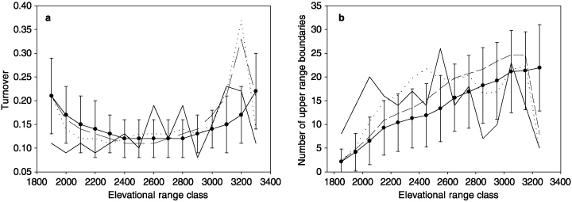

**Figure 5**

Variations of the simulation model. Shown are the distributions of the Wilson–Shmida index (a) and the upper elevational boundaries (b) for all plant groups together as observed (bold line), as simulated with constraining species richness per step and placement into layers (dotted line), only with constraining species richness (dashed line), and without any constraints (thin line).

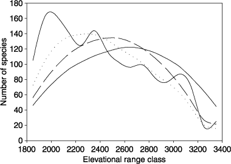

**Figure 6**

Distribution of species richness along the elevational gradient as observed (MMMean estimation) and as simulated with different variations of the simulation model's assumption (see Fig. 5 for description).

Mean elevational species range amplitude of 500 ± 368 m was low in comparison to other studies in the tropics where mean ranges of typically about 1000 m have been found (Lieberman *et al*., 1996; Sklenáø & Jørgensen, 1999; Hemp, 2002). This is probably due to the relatively short extent of the study transect, being limited below by the Huarinilla valley and at the top by forest‐free páramo vegetation. When species having their limits at the ends of the transect are eliminated, mean range size increases to 584 ± 367 m.

From a conservation perspective, the low level of congruence in the elevational distribution of different plant groups implies that no single plant group can be used as a reliable surrogate to take conservation decisions that would be valid for other groups. Furthermore, the different ecological mechanisms involved in determining the elevational distribution of different taxa suggest that the response to future climate change will be taxon‐specific, potentially endangering some groups more than others and leading to the formation of plant communities lacking modern analogues, as has been documented for past assemblages through pollen analyses (e.g. Bush *et al*., 2005).

In conclusion, our simulation approach provides an alternative approach for assessing the statistical significance of levels of species turnover along ecological gradient without the limitations imposed by traditional statistical approaches whose assumptions are rarely met in real‐life data sets (Legendre & Legendre, 1998). The new approach cannot only be applied to elevational transects, but to any other monotonically changing environmental gradients.

## ACKNOWLEDGEMENTS

We express our gratitude to A.R. Smith (ferns), T.B. Croat and A. Acebey (aroids), H.E. Luther and T. Krömer (bromeliads), S. Renner and F. Almeda (melastomes), M. Lehnert (*Cyathea*), and J. Gonzales (*Sticherus*) for species identifications, to J. Kluge for helpful discussions on the method, to M. Schawe and G. Gerold (University of Göttingen, Department of Landscape Ecology), and to M. Moraes, M. Baudoin, S. Beck, L. Pacheco, and many others in Bolivia (Instituto de Ecologia and Herbario Nacional, La Paz) for generous support and cooperation in this project. This study was financially supported by the German Research Foundation (DFG).

## Citing Literature

[Volume13, Issue6](https://onlinelibrary.wiley.com/toc/14724642/2007/13/6)

November 2007

Pages 863-870

### Metrics

- Citations: 14

### Keywords

  - [β‐diversity](https://onlinelibrary.wiley.com/action/doSearch?field1=Keyword&text1=%CE%B2%E2%80%90diversity)
  - Bolivia
  - [elevational belts](https://onlinelibrary.wiley.com/action/doSearch?field1=Keyword&text1=elevational%20belts)
  - simulation
  - [species turnover](https://onlinelibrary.wiley.com/action/doSearch?field1=Keyword&text1=species%20turnover)
  - [tropical montane cloud forests](https://onlinelibrary.wiley.com/action/doSearch?field1=Keyword&text1=tropical%20montane%20cloud%20forests)

### Publication History

  - Issue Online: 16 April 2007
  - Version of Record online: 16 April 2007